# Examen 3

```python
from pylab import *
%matplotlib inline
from scipy.special import *
```

# 1.-

Usaremos un for para i en [0,4] donde i es el orden de la función de Bessel y pondremos el plot dentro del for para que nos grafique todas en la misma figura.

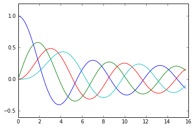

```python
x = linspace(0,5*pi,500)
for i in arange(4):
    y = jv(i,x)
    plot(x,y)
```

# 2.-

A continuación está la programación de la derivada, que hace exactamente lo que hace la definición de derivada.

```python
def derivada(ec,variable,h=0.01):
    df = (ec(variable + h) - ec(variable))/h
    return df
```

Y la ecuación para confirmar es:

```python
def ecuacion(x):
    return x**3 - 5*x + 2
```

Aquí se ve la gráfica de las tres ecuaciones, vemos que abajo la verde y la azul son indistinguibles, ya que la aroximación es buena.

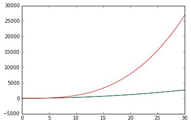

```python
y = linspace(0,30,1000)
dg = derivada(ecuacion,y)
dg2 = 3*(y**2) - 5
g = y**3 - 5*y + 2

plot(y,dg2,y,dg,y,g)
```

Quitando la función original, vemos que incluso para valores de h grandes, como 2 en este caso, la aproximación es buena.

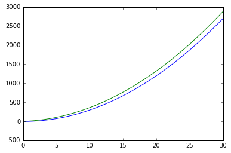

```python
y = linspace(0,30,1000)
dg = derivada(ecuacion,y,h=2)
dg2 = 3*(y**2) - 5
g = y**3 - 5*y + 2

plot(y,dg2,y,dg)
```

# 3.-

El siguiente código encuentra las raíces usando el método de Newton y la ecuación programada en el inciso 2. Hace el método hasta que el punto evaluado sea menor que el error.

```python
def newton(ec,p,err=0.001):

    raiz = p
    while abs(ec(raiz)) > err:
        raiz = raiz - ec(raiz)/derivada(ec,raiz)

    return raiz
```

```python
def ec2(x):
    return sin(3*x) + 0.5*cos(2*x)*cos(2*x)
```

Aquí vemos que los puntos encontrados son efectivamente las raíces de la función. Aquí se usó el for para tomar muchos puntos iniciales diferentes y obtener las raíces.

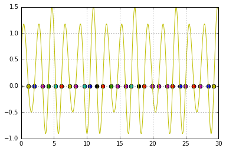

```python
w = linspace(0,30,1000)
for i in arange(600):
    raiz = newton(ec2,0.1*i)
    plot(raiz,0,'o')

plot(w,ec2(w))
xlim(0,30)
grid(True)
show()
```

# 4.-

Primero tomaremos como ec3 bessel de orden cero y ec4 su derivada.

```python
def ec3(x):
    return jv(0,x)

def ec4(x):
    return -jv(1,x)
```

Vemos que tomando la derivada numérica programada y el método de Newton anterior se encuentran las raíces.

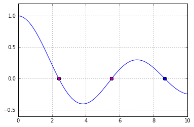

```python
ww = linspace(0,10,200)
plot(ww,jv(0,ww))
xlim(0,10)
grid(True)

for i in arange(600):
    raiz = newton(ec3,0.1*i)
    plot(raiz,0,'o')
```

Programamos un Newton especial donde se toma la derivada analítica.

```python
def newton_bessel(ec,p,err=0.001):

    raiz = p
    while abs(ec(raiz)) > err:
        raiz = raiz - ec(raiz)/ec4(raiz)

    return raiz
```

Vemos que aquí también se encuentran as raíces correctas.

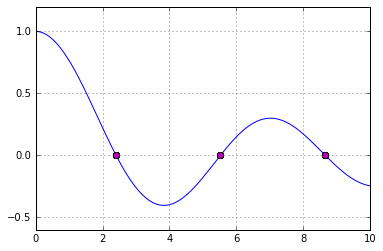

```python
ww = linspace(0,10,200)
plot(ww,jv(0,ww))
xlim(0,10)
grid(True)

for i in arange(600):
    raiz = newton_bessel(ec3,0.1*i)
    plot(raiz,0,'o')
```

Vemos que ambos métodos dan raíces muy similares. En este caso la primer raíz de manera con derivada numérica o analítica difieren en el cuarto decimal.

Numérica:

```python
newton(ec3,1)
```

```
2.4046317112393911
```

```python
jv(0,2.4046317112393911)
```

```
0.00010063895822988908
```

Analítica:

```python
newton_bessel(ec3,1)
```

```
2.4045555512049832
```

```python
jv(0,2.4045555512049832)
```

```
0.00014018106194076029
```

# 5.-

Sea una matriz

$$ \left( \begin{array}{ccc} a & b \\ c & d \end{array} \right) $$

que veremos aquí como:

[[a,b],[c,d]]

Sabemos que si el determinante es cero la matriz no tiene inversa, para lo cual se usa el primer if de la función. Si no, voltearemos los de la diagonal y les cambiaremos el signo a los otros.

```python
def inversa(matriz):

    if matriz[0][0]*matriz[1][1] - matriz[0][1]*matriz[1][0] == 0:
        print "No tiene matriz inversa"

    else:
        det_i = 1/(matriz[0][0]*matriz[1][1] - matriz[0][1]*matriz[1][0])
        a = matriz[1][1]*det_i
        b = -matriz[0][1]*det_i
        c = -matriz[1][0]*det_i
        d = matriz[0][0]*det_i

        print [[a,b],[c,d]]
```

Vemos del siguiente ejemplo que efectivamente nos da la matriz inversa. Es importante escribir los números con un punto porque si no no hace bien la división del determinante.

```python
mat = [[1.,2.],[3.,4.]]
inversa(mat)
```

```
[[-2.0, 1.0], [1.5, -0.5]]
```

# 6.-

Queremos primero convertir nuestro número en un entero, para eso si no es divisible entre uno lo multiplicamos por diez hasta que lo sea.

Luego le restamos uno a nuestro número hasta que sea divisible entre diez y cada paso que se hace lo vamos sumando a una "n". Cuando es divisible entre diez lo dividimos entre diez y repetimos. Así se suma cada dígito.

```python
def sumador(num):
    n = 0
    while num%1 != 0:
        num = num*10

    while num >= 1:
        while num%10 != 0:
            num = num - 1
            n += 1
        num = num*0.1

    return n
```

```python
sumador(124.0223)
```

```
14
```